# CleanUpRNAseq: detecting and correcting for gDNA contamination in RNA-seq data

# 3 How to run CleanUpRNAseq

First, load the required packages, including CleanUpRNAseq. Then users can perform a step-by-step analysis of the RNA-seq data as below for more flexibility. For users’ convenience, CleanUpRNAseq also offers two wrapper functions, create_diagnostic_plots and correct_for_contamination, for detecting and correcting for gDNA contamination in RNA-seq data. As for how to use these wrappers, please refer to their function documentation.

```r
suppressPackageStartupMessages({
    #library("CleanUpRNAseq")
    devtools::load_all("./")
    library("ggplotify")
    library("R.utils")
    library("patchwork")
})
```

## 3.1 Step 1: Load an EnsDb package or prepare an EnsDb database

Users can list all current EnsDb packages from *AnnotationHub* and load the package of choice, if available, as follows. Here, an EnsDb package for the human genome is loaded. It is crucial to use an EnsDb pacakge which represents the genome annotation file (GTF) used for RNA-seq read alignment.

```r
## load EnsDb.Hsapiens.v86
suppressPackageStartupMessages({
    library("EnsDb.Hsapiens.v86")
})
hs_ensdb_sqlite <- EnsDb.Hsapiens.v86
```

Otherwise, users can easily prepare an EnsDb database from an Ensembl GTF file. For all following steps, this option is adopted because the latest version of human transcriptome has been used for read mapping by STAR and Salmon to quantify gene expression of the example RNA-seq data.

```r
tmp_dir <- tempdir()
gtf_url <- paste0(
    "https://ftp.ensembl.org/pub/release-110/gtf/",
    "homo_sapiens/Homo_sapiens.GRCh38.110.gtf.gz"
)
gtf <- basename(gtf_url)
gtf <- file.path(tmp_dir, gtf)

if (!file.exists(gtf)) {
    download.file(
        url = gtf_url,
        destfile = gtf,
        mode = "wb"
    )
}

hs_ensdb_sqlite <- make_ensdb(
    gtf = gtf,
    outfile = file.path(
        tmp_dir,
        "EnsDb.hs.v110.sqlite"
    ),
    organism_latin_name = "Homo_Sapiens",
    genome_version = "GRCh38",
    Ensembl_release_version = 110
)
```

## 3.2 Step 2. Prepare SAF (simplified annotation format) files

Potential DNA contamination exists if a significantly high portion of RNA-seq reads mapped to intergenic regions. *CleanUpRNAseq* uses the *featureCounts* function from the *Rsubread* package to quantify the percentage of reads mapped to different genomic features: genes, exons, introns, intergenic regions, rRNA exons, and organelle genome(s). So users need to prepare SAF files for these genomic features. In addition, a BAM file is needed to provide the lengths of the chromosomes/scaffolds.

```r
bam_file <- system.file("extdata", "K084CD7PCD1N.srt.bam",
    package = "CleanUpRNAseq"
)
saf_list <- get_feature_saf(
    ensdb_sqlite = hs_ensdb_sqlite,
    bamfile = bam_file,
    mitochondrial_genome = "MT"
)
```

## 3.3 Step 3. Summarize reads mapped to different genomic features

Reads mapped to different genomic features is summarized by using the *featureCounts* function with the SAF files generated above as annotation. *CleanUpRNAseq* also quantifies the reads spanning exon-exon junctions and the reads mapped to exons of each gene using the GTF file as annotation. The junction read count table is used to determine the unexpressed, multiexonic genes, while the gene-level read count table is used for comparing samples at the gene level. Here two downsampled BAM files are used for speeding up the demonstration, while a precomputed R object in the .RData format is used for actual downstream analysis.

```r
bams <- system.file("extdata",
    c("K084CD7PCD1N.srt.bam", "K084CD7PCD1P.srt.bam"),
    package = "CleanUpRNAseq"
)

metadata <- data.frame(
    sample_name = c("CD1AN_m2_1", "CD1AP_m2_1"),
    BAM_file = bams,
    group = c("CD1AN", "CD1AP")
)
gunzip(gtf, remove = FALSE, overwrite = TRUE)

invisible({
    capture.output({
        counts_list <- summarize_reads(
            metadata = metadata,
            isPairedEnd = TRUE,
            strandSpecific = 0,
            saf_list = saf_list,
            gtf = gsub(".gz", "", gtf),
            threads = 1,
            verbose = FALSE
        )
    })
})
```

## 3.4 Step 4. Check DNA contamination

A precomputed R object in the .RData format (*read_count_summary.RData*) containing the *featureCounts* output for a full RNA-seq dataset of 8 samples from two treatment groups is downloaded from Dropbox.

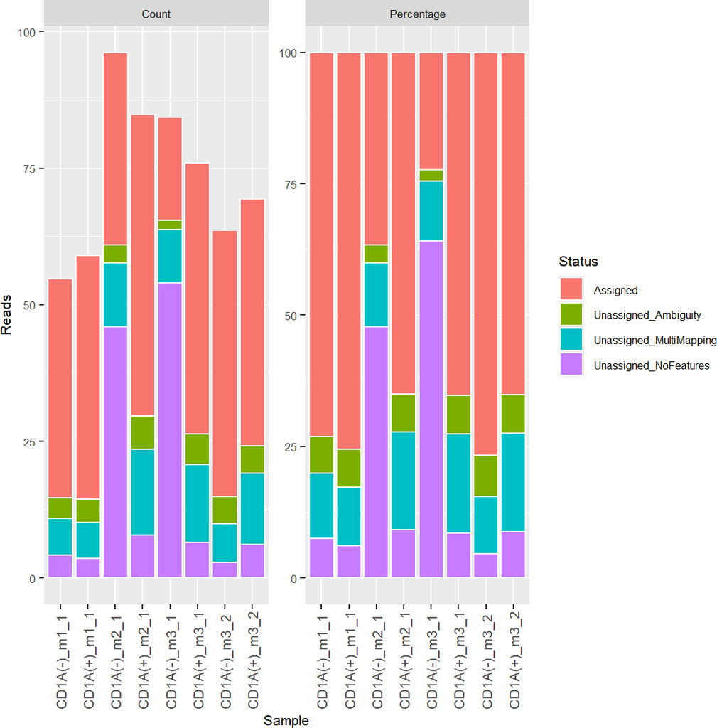

Figure 1: Read mapping status

```r
## download feaureCounts results
count_url <- paste0(
    "https://www.dropbox.com/scl/fi/lyvh6bsljnqxtq85nnugq/",
    "read_count_summary.RData?rlkey=e0tmpehpxtnr1fdx4fz0h8sa0&dl=1"
)
download.file(
    url = count_url,
    destfile = file.path(tmp_dir, "read_count_summary.RData"),
    mode = "wb"
)
load(file.path(tmp_dir, "read_count_summary.RData"))


p_assignment_stat <-
    check_read_assignment_stat(assignment_stat = counts_summary$gtf$stat)
wrap_plots(p_assignment_stat)
```

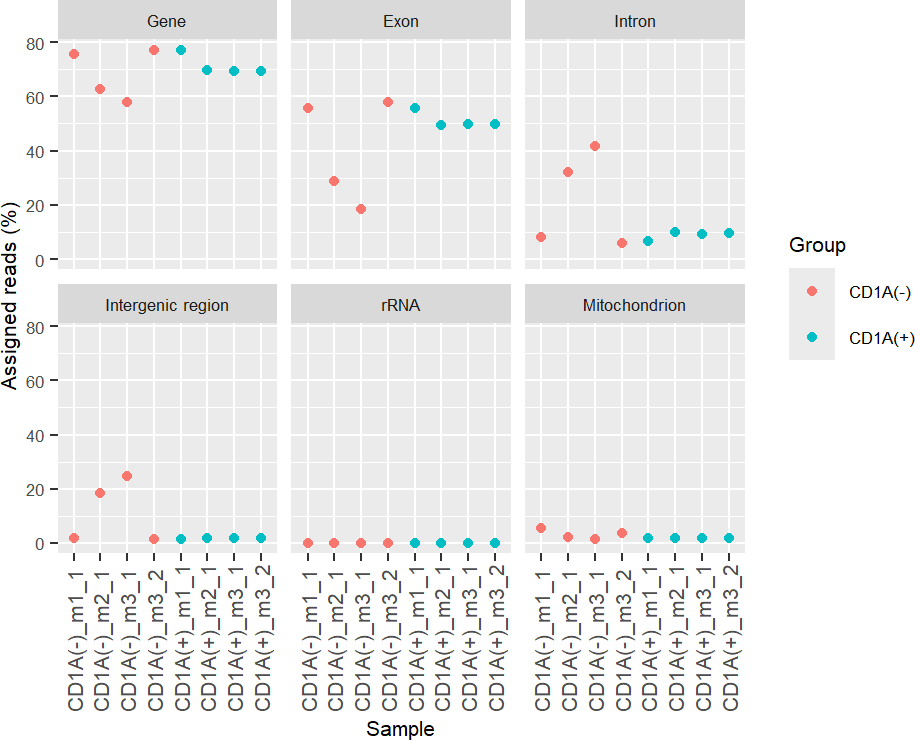

Figure 2: Read distribution over different genomic features

```r
metadata <- counts_summary$metadata
counts_summary$metadata <- NULL
p_read_distr <- check_read_distribution(
    featurecounts_list = counts_summary,
    metadata = metadata
)
print(p_read_distr$p)
```

```r
quant_files <- system.file("extdata",
    c("K084CD7PCD1N.quant.sf", "K084CD7PCD1P.quant.sf"),
    package = "CleanUpRNAseq"
)

metadata_toy <- data.frame(
    sample_name = c("CD1AN_m2_1", "CD1AP_m2_1"),
    salmon_quant_file = quant_files,
    group = c("CD1AN", "CD1AP")
)

salmon_counts <- salmon_res(
    metadata = metadata_toy,
    ensdb_sqlite = hs_ensdb_sqlite
)

## download the full Salmon quantification data

salmon_url <-
    paste0("https://drive.google.com/uc?export=download&id=13vsobXnENoiYOBo-",
           "Vf_e_00xbR8ekc4Z")
destfile <- file.path(tmp_dir, "salmon_quant_summary.RData")
download.file(
    url = salmon_url,
    destfile = destfile,
    mode = "wb"
)

## load the salmon_quant object
load(destfile)
```

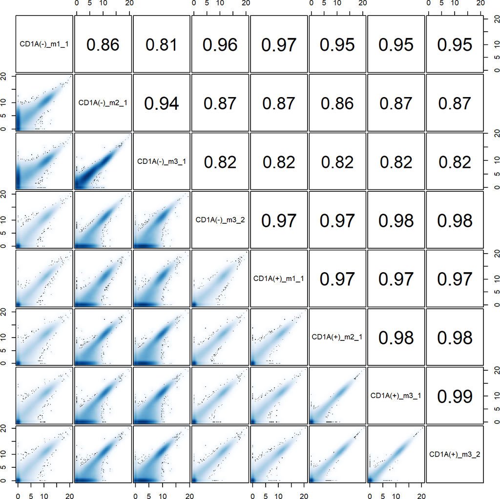

Figure 3: Smoothed scatter plot showing pairwise sample correlation

```r
check_sample_correlation(counts = salmon_quant$counts)
```

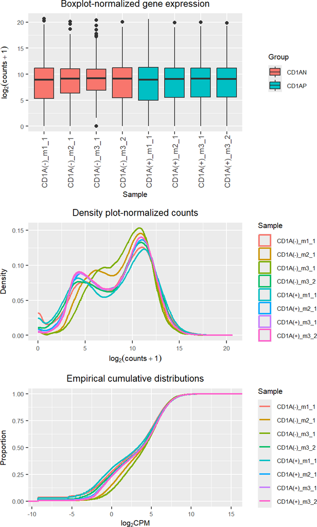

Figure 4: Expression distribution

```r
metadata$group <- gsub("CD1A\\(-\\)", "CD1AN", metadata$group)
metadata$group <- gsub("CD1A\\(\\+\\)", "CD1AP", metadata$group)
p_expr_distr <- check_expr_distribution(
    counts = salmon_quant$counts,
    metadata = metadata
)
wrap_plots(p_expr_distr, ncol = 1, nrow = 3)
```

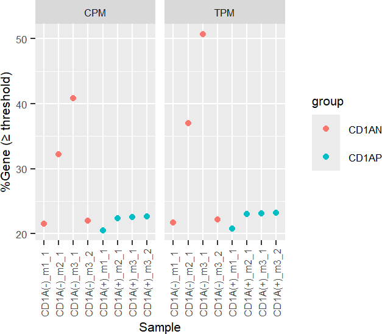

Figure 5: Percent of expressed genes

```r
p_expr_genes <-
    check_expressed_gene_percentage(
        metadata = metadata,
        counts = salmon_quant$counts,
        min_cpm = 1,
        abundance = salmon_quant$abundance,
        min_tpm = 1
    )
print(p_expr_genes)
```

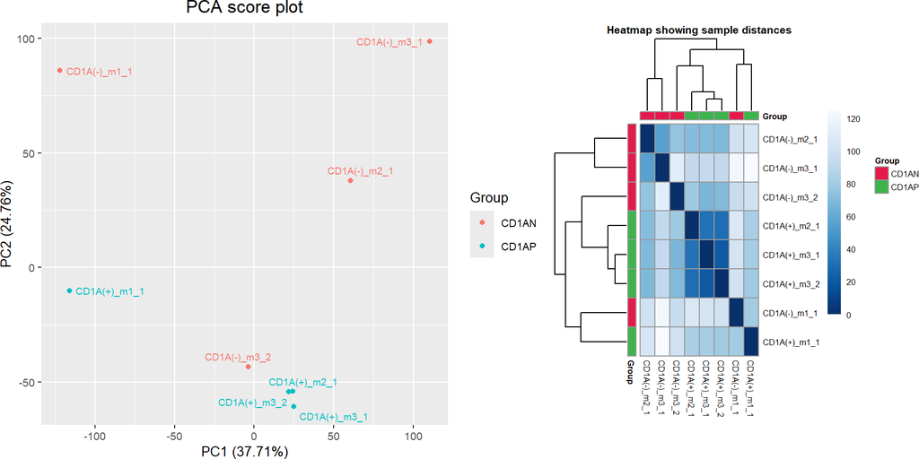

Figure 6: PCA score plot and heatmap showing sample similarity

```r
## DESeq2 exploratory analysis before correction
pca_heatmap <- exploratory_analysis(
    counts = salmon_quant$counts,
    metadata = metadata
)
pca_heatmap$pca + as.ggplot(pca_heatmap$heatmap)
```

## 3.5 Step 5. Correct for DNA contamination

If the libraries are unstranded, *CleanUpRNAseq* uses a median per-base read coverage (median_PBRC) over non-zero count intergenic regions to estimate per-base DNA contamination over exons of each gene of each sample, and corrects for gene-level DNA contamination by subtracting median_PBRC * average_gene_length from the Salmon count table of each gene of each sample.

```r
corrected_counts <- global_correction(
    intergenic_featureCounts_res =
        counts_summary$intergenic_region,
    salmon_res = salmon_quant
)
```

However, if the libraries are stranded, *CleanUpRNAseq* considered as gene-level contamination the count table resulted from quantitation using the opposite strandedness setting. By subtracting the DNA contamination of each gene in each sample from the count table resulted from quantitation using the actual strandedness setting, users can get contamination corrected count table. To this end, use the `correct_stranded_lib` function.

## 3.6 Step 6. Check correction effect

After correcting for DNA contamination, we expect to see more comparable gene expression across samples.

Boxplots, density plots and empirical cumulative distribution after correction revealed gene expression across samples are more comparable.

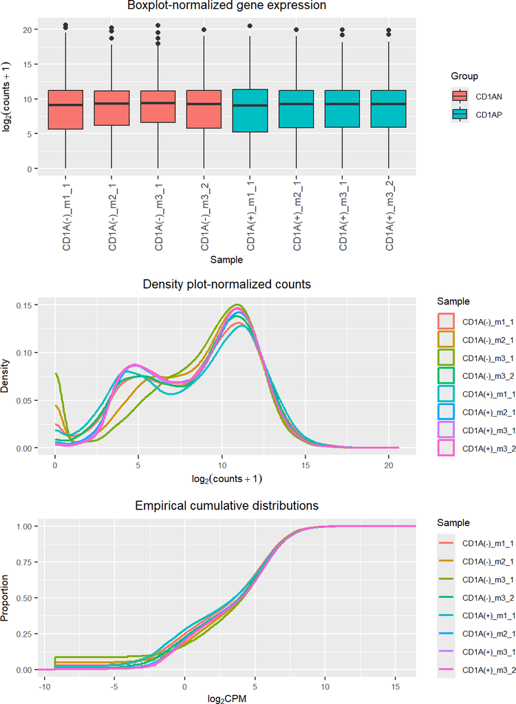

Figure 7: Expression distribution after correction

```r
metadata$group <- gsub("CD1A\\(-\\)", "CD1AN", metadata$group)
metadata$group <- gsub("CD1A\\(\\+\\)", "CD1AP", metadata$group)
p_expr_distr <- check_expr_distribution(
    counts = corrected_counts,
    metadata = metadata
)
wrap_plots(p_expr_distr, ncol = 1, nrow = 3)
```